# ECON622: Problem Set 3

Jesse Perla, UBC

## Student Name/Number: Wan-Chiao Chang / 17065012

# Packages

Add whatever packages you wish here

```python
import numpy as np
import matplotlib.pyplot as plt
import jax
import jax.numpy as jnp
from jax import grad, jvp, vjp
from jax import random
from numpy.linalg import cond
```

## Question 1: Conditioning and Preconditioned Gradient Descent

In this question, you will explore how the condition number affects gradient descent convergence and implement a simple diagonal preconditioner to improve performance.

We consider minimizing the quadratic function:

$$ f(x) = \frac{1}{2} x^\top P x $$

where $P$ is a symmetric positive definite matrix. The gradient is $\nabla f(x) = P x$, so the minimum is at $x^* = 0$.

### Starter Code

The following function visualizes gradient descent on a 2D quadratic:

```python
def plot_gd_steps(N_steps, x_0, Lambda, eta):
    """
    Plot gradient descent steps on a 2D quadratic f(x) = 0.5 * x^T P x
    where P = Q @ diag(Lambda) @ Q^T for a 45-degree rotation Q.

    Args:
        N_steps: Number of GD iterations to plot
        x_0: Initial point [x1, x2]
        Lambda: Eigenvalues [lambda1, lambda2] (condition number = max/min)
        eta: Step size (learning rate)
    """
    Q = np.array([[np.sqrt(2)/2, np.sqrt(2)/2],
                  [-np.sqrt(2)/2, np.sqrt(2)/2]])
    P = Q @ np.diag(Lambda) @ Q.T
    gd_step = lambda x: x - eta * P @ x

    x_vals = np.linspace(-1, 1, 100)
    X1, X2 = np.meshgrid(x_vals, x_vals)
    Z = 0.5 * (P[0,0]*X1**2 + 2*P[0,1]*X1*X2 + P[1,1]*X2**2)

    plt.figure(figsize=(6, 5))
    plt.contour(X1, X2, Z, levels=20, cmap='viridis')

    x_current = np.array(x_0)
    for i in range(N_steps):
        x_next = gd_step(x_current)
        plt.arrow(x_current[0], x_current[1],
                  x_next[0] - x_current[0], x_next[1] - x_current[1],
                  head_width=0.03, head_length=0.02, fc='red', ec='red')
        x_current = x_next

    plt.xlabel('x1'); plt.ylabel('x2')
    plt.gca().set_aspect('equal')
    return plt.gcf()
```

### Question 1.1: Explore Conditioning Visually

Run the visualization with different condition numbers and observe how the contours change shape.

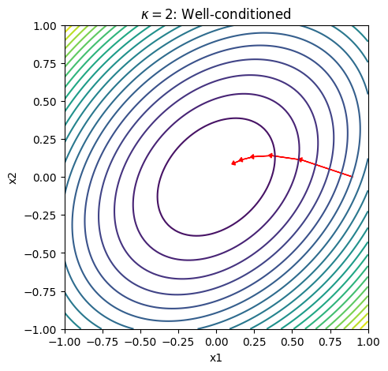

```python
x_0 = [0.9, 0.0]
eta = 0.5

# Well-conditioned: kappa = 2
Lambda_good = np.array([1.0, 0.5])
plot_gd_steps(5, x_0, Lambda_good, eta)
plt.title(r'$\kappa = 2$: Well-conditioned')
plt.show()
```

Now run with $\kappa = 10$ (eigenvalues [1.0, 0.1]) and $\kappa = 100$ (eigenvalues [1.0, 0.01]).

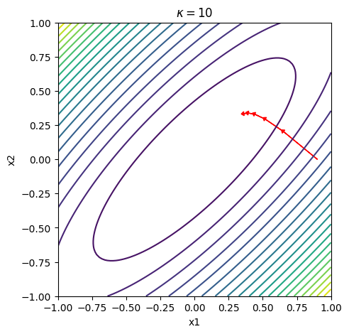

```python
# Well-conditioned: kappa = 10
Lambda_good = np.array([1.0, 0.1])
plot_gd_steps(5, x_0, Lambda_good, eta)
plt.title(r'$\kappa = 10$')
plt.show()
```

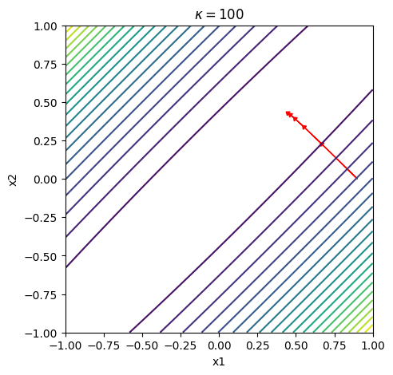

```python
# Well-conditioned: kappa = 100
Lambda_good = np.array([1.0, 0.01])
plot_gd_steps(5, x_0, Lambda_good, eta)
plt.title(r'$\kappa = 100$')
plt.show()
```

Explain in 2-3 sentences why gradient descent struggles with poorly-conditioned problems (narrow ellipses).

Answer: When the problem is poorly conditioned, the loss surface looks like a long, narrow valley. In this case, gradient descent keeps stepping back and forth across the steep sides instead of moving straight toward the minimum, which makes progress slow. To avoid overshooting in the steep direction, the step size must also be kept small, but then this further slowing convergence.

### Question 1.2: Count Iterations to Convergence

Use the following function to count how many iterations GD needs to converge:

```python
def count_gd_iterations(x_0, P, eta, tol=1e-6, max_iter=1000):
    """Count iterations until ||x|| < tol"""
    x = np.array(x_0)
    for i in range(max_iter):
        if np.linalg.norm(x) < tol:
            return i
        x = x - eta * P @ x
    return max_iter  # didn't converge
```

Helper function to create $P$ from eigenvalues:

```python
def make_P(Lambda):
    """Create P = Q @ diag(Lambda) @ Q^T"""
    Q = np.array([[np.sqrt(2)/2, np.sqrt(2)/2],
                  [-np.sqrt(2)/2, np.sqrt(2)/2]])
    return Q @ np.diag(Lambda) @ Q.T
```

```python
x_0 = [0.9, 0.0]
eta = 0.5

for kappa, Lambda in [(2, [1.0, 0.5]), (10, [1.0, 0.1]), (100, [1.0, 0.01])]:
    P = make_P(np.array(Lambda))
    iters = count_gd_iterations(x_0, P, eta)
    print(f"kappa = {kappa}: {iters} iterations")
```

```
kappa = 2: 47 iterations
kappa = 10: 261 iterations
kappa = 100: 1000 iterations
```

Report the iteration counts and explain the relationship between $\kappa$ and convergence rate.

### Question 1.3 (BONUS): Understand Preconditioned Gradient Descent

Standard gradient descent updates:

$$ x^{k+1} = x^k - \eta \nabla f(x^k) = x^k - \eta P x^k $$

**Preconditioned gradient descent** scales the gradient by a matrix $D^{-1}$:

$$ x^{k+1} = x^k - \eta D^{-1} \nabla f(x^k) = x^k - \eta D^{-1} P x^k $$

**Your task:** Show that preconditioned GD is equivalent to standard GD on a transformed problem.

Let $\tilde{x} = D^{1/2} x$ (assuming $D$ is diagonal with positive entries). Show that:

1. The objective becomes $\tilde{f}(\tilde{x}) = \frac{1}{2} \tilde{x}^\top \tilde{P} \tilde{x}$ where $\tilde{P} = D^{-1/2} P D^{-1/2}$
2. If we choose $D = \text{diag}(P)$, what are the diagonal entries of $\tilde{P}$?

**(double click to edit your answer)**

Derivation:

1. Objective The original objective function is:

$$f(x) = \frac{1}{2} x^\top P x$$ If we substitute variables $x as D^{-1/2} \tilde{x}$:

$$\tilde{f}(\tilde{x}) = \frac{1}{2} (D^{-1/2} \tilde{x})^\top P (D^{-1/2} \tilde{x})$$ $$\tilde{f}(\tilde{x}) = \frac{1}{2} \tilde{x}^\top (D^{-1/2})^\top P D^{-1/2} \tilde{x}$$

Since $D$ is a diagonal matrix, $D^{-1/2}$ is also diagonal and symmetric, meaning $(D^{-1/2})^\top = D^{-1/2}$. By defining $\tilde{P} = D^{-1/2} P D^{-1/2}$, we obtain:

$$\tilde{f}(\tilde{x}) = \frac{1}{2} \tilde{x}^\top \tilde{P} \tilde{x}$$

2. Diagonal Entries of $\tilde{P}$ We can write the elements of $\tilde{P}$ as:

$$\tilde{P}_{ij} = \frac{P_{ij}}{\sqrt{D_{ii}}\sqrt{D_{jj}}}$$ For the diagonal entries ($i = j$):

$$\tilde{P}_{ii} = \frac{P_{ii}}{D_{ii}}$$ If we choose $D = \text{diag}(P)$, then $D_{ii} = P_{ii}$ for all $i$. Substituting this into the equation:

$$\tilde{P}_{ii} = \frac{P_{ii}}{P_{ii}} = 1$$ That is, all diagonal entries of $\tilde{P}$ are 1.

### Question 1.4: Implement Diagonal Preconditioning

Implement preconditioned GD and compare iteration counts:

```python
def count_preconditioned_gd_iterations(x_0, P, D_inv, eta, tol=1e-6, max_iter=10000):
    """Count iterations for preconditioned GD: x_{k+1} = x_k - eta * D^{-1} @ P @ x_k"""
    x = np.array(x_0)
    for i in range(max_iter):
        if np.linalg.norm(x) < tol:
            return i
        # modify here: implement preconditioned step
        grad = P @ x
        x = x - eta * (D_inv @ grad)
    return max_iter
```

Test with $\kappa = 100$:

```python
Lambda = np.array([1.0, 0.01])
P = make_P(Lambda)
D_inv = np.diag(1.0 / np.diag(P))  # D^{-1} where D = diag(P)

# modify here: compare iterations with and without preconditioning
x_0 = np.array([1.0, 1.0])
eta = 0.5  # Stable step size

# Standard GD: D_inv is Identity
iters_standard = count_preconditioned_gd_iterations(x_0, P, np.eye(2), eta)

# Preconditioned GD: D_inv = diag(P)^{-1}
iters_preconditioned = count_preconditioned_gd_iterations(x_0, P, D_inv, eta)

print(f"Standard GD iterations: {iters_standard}")
print(f"Preconditioned GD iterations: {iters_preconditioned}")
```

```
Standard GD iterations: 2826
Preconditioned GD iterations: 1424
```

### Question 1.5: Verify the Condition Number Improvement

Compute and compare the condition numbers before and after preconditioning:

```python
Lambda = np.array([1.0, 0.01])
P = make_P(Lambda)
D = np.diag(np.diag(P))
D_sqrt_inv = np.diag(1.0 / np.sqrt(np.diag(P)))

# Preconditioned matrix: D^{-1/2} P D^{-1/2}
P_precond = D_sqrt_inv @ P @ D_sqrt_inv

# modify here: compute and print condition numbers
# Compute and print condition numbers
cond_P = cond(P)
cond_P_precond = cond(P_precond)

print(f"cond(P) = {cond_P:.2f}")
print(f"cond(P_precond) = {cond_P_precond:.2f}")
```

```
cond(P) = 100.00
cond(P_precond) = 100.00
```

**(double click to edit your answer)**

Explain why the diagonal preconditioner improves the condition number for this problem.

Answer: Even though the condition number didn't change, from Question 1.4 we see that the convergence is faster after preconditioning. This is because the preconditioning rescaled the problem such that the fixed step size η=0.5 became closer to the optimal step size for the system.

## Question 2: Vectorized AD Rule for Matrix-Vector Product

In this question, you will derive the JVP and VJP rules for a vectorized operation (matrix-vector multiplication) and verify your implementation against JAX.

Consider the function $f(A, x) = Ax$ where $A \in \mathbb{R}^{m \times n}$ and $x \in \mathbb{R}^n$.

### Question 2.1: Derive the JVP Rule

Given tangents $\dot{A} \in \mathbb{R}^{m \times n}$ and $\dot{x} \in \mathbb{R}^n$, derive the pushforward (JVP):

$$ \dot{y} = \partial f(A, x)[(\dot{A}, \dot{x})] = ? $$

**Hint:** Use the product rule for differentiation.

**(double click to edit your answer)**

Derivation: Based on the matrix product rule $d(UV) = (dU)V + U(dV)$, we can write the differential $dy$ as: $$dy = d(Ax) = (dA)x + A(dx)$$

Then, we replace the differentials $dy, dA, dx$ with their respective tangents $\dot{y}, \dot{A}, \dot{x}$: $$\dot{y} = \dot{A}x + A\dot{x}$$

This is the JVP rule for matrix-vector multiplication.

### Question 2.2 (BONUS): Derive the VJP Rule

Given a cotangent $\bar{y} \in \mathbb{R}^m$, derive the pullback (VJP):

$$ (\bar{A}, \bar{x}) = \partial f(A, x)^\top[\bar{y}] = ? $$

**Hint for adjoint algebra:** Start with the inner product $\langle \bar{y}, \dot{y} \rangle = \langle \bar{y}, \dot{A} x + A \dot{x} \rangle$ and rearrange to identify $\bar{A}$ and $\bar{x}$.

Recall that for matrices, $\langle U, V \rangle = \text{Tr}(U^\top V)$, and for vectors, $\langle u, v \rangle = u^\top v$.

**(double click to edit your answer)**

Derivation:

From Question 2.1, we have $\dot{y} = \dot{A}x + A\dot{x}$. Substitute into the inner product: $$\langle \bar{y}, \dot{y} \rangle = \langle \bar{y}, \dot{A}x + A\dot{x} \rangle = \langle \bar{y}, \dot{A}x \rangle + \langle \bar{y}, A\dot{x} \rangle$$ For the first term: $$\langle \bar{y}, \dot{A}x \rangle = \text{Tr}(\bar{y}^\top \dot{A} x) = \text{Tr}(x \bar{y}^\top \dot{A}) = \langle \bar{y}x^\top, \dot{A} \rangle$$ Thus, $\bar{A} = \bar{y}x^\top$. For the second term: $$\langle \bar{y}, A\dot{x} \rangle = \langle A^\top \bar{y}, \dot{x} \rangle$$ Thus, $\bar{x} = A^\top \bar{y}$. Therefore, the VJP rule for $f(A, x) = Ax$ is:

$$\bar{A} = \bar{y} x^\top$$

$$\bar{x} = A^\top \bar{y}$$

### Question 2.3: Implement and Verify JVP

Implement your JVP rule and verify against JAX:

```python
def matvec(A, x):
    """f(A, x) = A @ x"""
    return A @ x

def matvec_jvp(A, x, A_dot, x_dot):
    """Your implementation of the JVP rule: returns y_dot"""
    y_dot = A_dot @ x + A @ x_dot
    return y_dot

# Test data
key = random.PRNGKey(42)
keys = random.split(key, 4)
m, n = 4, 3
A = random.normal(keys[0], (m, n))
x = random.normal(keys[1], (n,))
A_dot = random.normal(keys[2], (m, n))
x_dot = random.normal(keys[3], (n,))

# modify here: compare to JAX jvp
y, jax_y_dot = jax.jvp(matvec, (A, x), (A_dot, x_dot))

# Compare results
my_y_dot = matvec_jvp(A, x, A_dot, x_dot)
is_correct = jnp.allclose(my_y_dot, jax_y_dot)

print(f"Manual JVP result:\n{my_y_dot}")
print(f"JAX JVP result:\n{jax_y_dot}")
print(f"Implementation correct: {is_correct}")
```

```
Manual JVP result:
[ 0.30276608  0.11958396  2.7425175  -0.5717054 ]
JAX JVP result:
[ 0.30276608  0.11958396  2.7425175  -0.5717054 ]
Implementation correct: True
```

### Question 2.4: Implement and Verify VJP

Implement your VJP rule and verify against JAX:

```python
def matvec_vjp(A, x, y_bar):
    """Your implementation of the VJP rule: returns (A_bar, x_bar)"""
    A_bar = np.outer(y_bar, x)
    x_bar = A.T @ y_bar
    return A_bar, x_bar

# Test cotangent
y_bar = random.normal(random.PRNGKey(99), (m,))

# modify here: compare to JAX vjp
f = lambda A, x: A @ x
y, vjp_fun = jax.vjp(f, A, x)
jax_A_bar, jax_x_bar = vjp_fun(y_bar)

# Check correctness
print(f"A_bar correct: {np.allclose(jax_A_bar, matvec_vjp(A, x, y_bar)[0])}")
print(f"x_bar correct: {np.allclose(jax_x_bar, matvec_vjp(A, x, y_bar)[1])}")
```

```
A_bar correct: True
x_bar correct: True
```

**(double click to edit your answer)**

Explain in 2-3 sentences the connection between the VJP formula $\bar{x} = A^\top \bar{y}$ and the “adjoint” or “transpose” terminology used in automatic differentiation.

Answer: The term "adjoint" is used because the VJP is mathematically the adjoint operator of the Jacobian. In the specific case of a linear operation $Ax$, the Jacobian is simply the matrix $A$, and its adjoint is the transpose $A^\top$. This explains why the backward pass through a matrix multiplication involves multiplying by the transpose of that matrix.

## Question 3 (BONUS): Sensitivity Analysis via the LLS Adjoint

In this question, you will derive and apply the VJP (adjoint) rule for linear least squares to perform sensitivity analysis: understanding how each observation affects the estimated coefficients.

### The Linear Least Squares Problem

Given design matrix $X \in \mathbb{R}^{n \times p}$ and observations $y \in \mathbb{R}^n$, the least squares solution is:

$$ \hat{\beta} = (X^\top X)^{-1} X^\top y $$

### Question 3.1: The LLS Adjoint Rule

The VJP rule for $\hat{\beta} = \text{LLS}(X, y)$ is derived by chaining through the matrix inverse and products.

**Given:** A cotangent $\bar{\beta} \in \mathbb{R}^p$ (representing “how much we care about each coefficient”)

**Compute:**

1. Solve the linear system: $g = (X^\top X)^{-1} \bar{\beta}$
2. Compute the residual: $r = y - X\hat{\beta}$

**Then the adjoints are:**

$$ \bar{y} = X g $$

$$ \bar{X} = r\, g^\top - (Xg)\, \hat{\beta}^\top $$

**(double click to edit your answer)**

Explain in 2-3 sentences why this is computationally powerful: if we want to know how $\hat{\beta}_0$ depends on ALL $n$ observations $y_i$, how many backward passes do we need?

Answer: The adjoint/VJP approach is powerful because it allows us to compute the sensitivity of a scalar output (like $\hat{\beta}_0$) with respect to all n input observations $y_i$ in a single backward pass.

### Question 3.2: Generate Data and Compute LLS

```python
# Generate random regression data
key = random.PRNGKey(123)
keys = random.split(key, 3)

n = 1000  # observations
p = 3     # parameters

# True coefficients
beta_true = jnp.array([2.0, -1.0, 0.5])

# Random design matrix and noisy observations
X = random.normal(keys[0], (n, p))
noise = 0.1 * random.normal(keys[1], (n,))
y = X @ beta_true + noise

# Compute LLS solution
beta_hat = jnp.linalg.lstsq(X, y)[0]
print(f"True beta: {beta_true}")
print(f"Estimated beta: {beta_hat}")
```

```
True beta: [ 2.  -1.   0.5]
Estimated beta: [ 2.0004644 -1.0009894  0.4901927]
```

### Question 3.3: Manual Sensitivity Calculation

Use the LLS adjoint rule to compute $\partial \hat{\beta}_0 / \partial y_i$ for all observations.

```python
# We want sensitivity of beta_hat[0] to each y_i
# Set beta_bar = e_0 = [1, 0, 0]
beta_bar = jnp.array([1.0, 0.0, 0.0])

# modify here: compute g, r, and y_bar using the adjoint formula

# 1. Solve the linear system: g = (X^T X)^{-1} beta_bar
# Using jnp.linalg.solve for numerical stability
g = jnp.linalg.solve(X.T @ X, beta_bar)

# 2. Compute the residual: r = y - X @ beta_hat
r = y - X @ beta_hat

# 3. Compute y_bar (sensitivity of beta_hat[0] to each y_i)
# y_bar = X @ g
y_bar_manual = X @ g
```

### Question 3.4: Verify with JAX VJP

Use JAX’s built-in autodiff to verify your manual calculation:

```python
def lls(y):
    """LLS as a function of y only (X is fixed)"""
    return jnp.linalg.lstsq(X, y)[0]

# modify here: use vjp to compute sensitivity of beta_hat[0] to y

# Use vjp to compute sensitivity
beta_hat_jax, vjp_fun = vjp(lls, y)
y_bar_jax, = vjp_fun(beta_bar)

# Verification
print(f"Implementation correct: {jnp.allclose(y_bar_manual, y_bar_jax)}")
```

```
Implementation correct: True
```

### Question 3.5: Interpret the Sensitivities

Plot the sensitivities and identify influential observations:

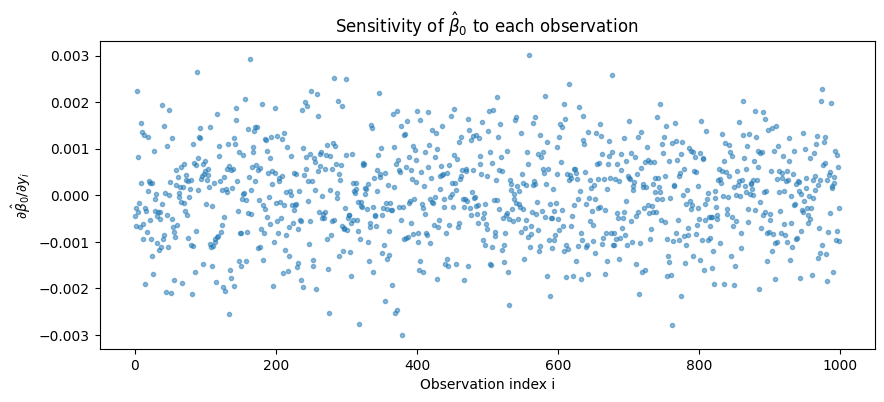

```python
# modify here: create a plot showing the sensitivities
plt.figure(figsize=(10, 4))
plt.plot(y_bar_manual, 'o', alpha=0.5, markersize=3)
plt.xlabel('Observation index i')
plt.ylabel(r'$\partial \hat{\beta}_0 / \partial y_i$')
plt.title('Sensitivity of $\\hat{\\beta}_0$ to each observation')
plt.show()

# Find the most influential observations
top_indices = jnp.argsort(jnp.abs(y_bar_manual))[-5:]
```

**(double click to edit your answer)**

1. What determines whether an observation has high sensitivity (large $|\partial \hat{\beta}_0 / \partial y_i|$)? Answer: An observation $y_i$ has high sensitivity if its corresponding row in the design matrix, $x_i$, is "large" or "unique" in the direction of the coefficient we are interested in ($\hat{\beta}_0$). This is mathematically captured by $\bar{y} = X(X^\top X)^{-1}\bar{\beta}$.
2. How does this relate to the concept of “leverage” in regression diagnostics? Answer: They are relevant becasue high-leverage points are those with $x_i$ values far from the mean, meaning they have a disproportionate influence on the slope and intercept of the regression line.

### Question 3.6 (Extra Credit): Sensitivity to X

The full adjoint rule also gives $\bar{X}$. Compute and interpret the sensitivity of $\hat{\beta}_0$ to changes in $X_{ij}$.

```python
# modify here: compute X_bar using the full adjoint formula
# X_bar = r @ g.T - (X @ g) @ beta_hat.T
# This gives d(beta_hat[0])/d(X_ij) for all i,j
X_bar = jnp.outer(r, g) - jnp.outer(X @ g, beta_hat)
```

**(double click to edit your answer)**

What is the computational advantage of using the adjoint/VJP approach for this sensitivity analysis compared to finite differences?

Answer: The adjoint approach computes all $n \times p$ sensitivities in the design matrix simultaneously. Using finite differences would require $n \times p$ (e.g., 3,000) separate re-evaluations of the least-squares solver, which is way more expensive than the VJP approach.